# IB_R_Project1

**Preparation to the analysis**. Installing package to read csv.files and plot graphs.

```r
library('readr')
```

```r
library('ggplot2')
library('cowplot')
```

**Step 1. Retrieving of data** Writing function to create a data frame representing the result of merging files. The function accesses a zipped folder (by argument path), unpacks it and extracts files of a specified extension (by argument file_type). Then the function reads files one by one, creates corresponding dataframe and finally combines it to one data frame. Here the usage of the function is shown on olympic games results data.

```r
merge_files = function(path,file_type){
  files <- unzip(zipfile = path, files = file_type, list=TRUE)
  df_fin = data.frame()
  datalist = list()
  for (f in files$Name){
    print(f)
    df = read.csv(unzip(zipfile = path, files =f))
    df_fin = rbind(df_fin,df)
  }
  return(df_fin)
}
a_data = merge_files("D:/IB2021_2022/R_statistics/Sasha/athlete_events.zip","*.csv")
```

```
## [1] "athlete_events00.csv"
## [1] "athlete_events01.csv"
## [1] "athlete_events02.csv"
## [1] "athlete_events03.csv"
## [1] "athlete_events04.csv"
## [1] "athlete_events05.csv"
## [1] "athlete_events06.csv"
## [1] "athlete_events07.csv"
## [1] "athlete_events08.csv"
## [1] "athlete_events09.csv"
## [1] "athlete_events10.csv"
## [1] "athlete_events11.csv"
```

**Step 2. Data quality check** The data is checked using summary function which provides the basic statistics overview for all variables. With the analysis, unreasonable results were found: Age values of 240, Height values of 340. These entries were replaced with NA as we can not guess the real values. Then the columns containing limited amount of factor-like values (Sport, Sex, Medal, City) are checked in order to detect any unreasonable entries. The obviously mistyped sport type “Footba” was replaced with “Football”. Rows containing values corresponding to “Art Competitions” were also removed as not considering as a type of olympic sports. The alternative to these quality checks could be plotting boxplots for each quantitative variable to detect outliers or extracting the data on olympic games sports types, participants names, cities and so on and comparing with the provided data.

```r
summary(a_data)
```

```
##        ID             Name               Sex                 Age
##  Min.   :     1   Length:271115      Length:271115      Min.   : 10.00
##  1st Qu.: 34643   Class :character   Class :character   1st Qu.: 21.00
##  Median : 68205   Mode  :character   Mode  :character   Median : 24.00
##  Mean   : 68249                                         Mean   : 25.56
##  3rd Qu.:102097                                         3rd Qu.: 28.00
##  Max.   :135571                                         Max.   :240.00
##                                                         NA's   :9476
##      Height          Weight          Team               NOC
##  Min.   :127.0   Min.   :  7.0   Length:271115      Length:271115
##  1st Qu.:168.0   1st Qu.: 60.0   Class :character   Class :character
##  Median :175.0   Median : 70.0   Mode  :character   Mode  :character
##  Mean   :175.3   Mean   : 70.7
##  3rd Qu.:183.0   3rd Qu.: 79.0
##  Max.   :340.0   Max.   :214.0
##  NA's   :60172   NA's   :62876
##     Games                Year         Season              City
##  Length:271115      Min.   :1896   Length:271115      Length:271115
##  Class :character   1st Qu.:1960   Class :character   Class :character
##  Mode  :character   Median :1988   Mode  :character   Mode  :character
##                     Mean   :1978
##                     3rd Qu.:2002
##                     Max.   :2016
##                     NA's   :7
##     Sport              Event              Medal
##  Length:271115      Length:271115      Length:271115
##  Class :character   Class :character   Class :character
##  Mode  :character   Mode  :character   Mode  :character
##
##
##
##
```

```r
unique(a_data$Sport)
```

```
##  [1] "Basketball"                "Judo"
##  [3] "Football"                  "Tug-Of-War"
##  [5] "Speed Skating"             "Cross Country Skiing"
##  [7] "Athletics"                 "Ice Hockey"
##  [9] "Swimming"                  "Badminton"
## [11] "Sailing"                   "Biathlon"
## [13] "Gymnastics"                "Art Competitions"
## [15] "Alpine Skiing"             "Handball"
## [17] "Weightlifting"             "Wrestling"
## [19] "Luge"                      "Water Polo"
## [21] "Hockey"                    "Rowing"
## [23] "Bobsleigh"                 "Fencing"
## [25] "Equestrianism"             "Shooting"
## [27] "Boxing"                    "Taekwondo"
## [29] "Cycling"                   "Diving"
```

[output cut: 19 more lines]

```r
unique(a_data$Sex)
```

```
## [1] "M" "F" "G" ""
```

```r
unique(a_data$Medal)
```

```
## [1] NA       "Gold"   "Bronze" "Silver" ""
```

```r
unique(a_data$City)
```

```
##  [1] "Barcelona"              "London"                 "Antwerpen"
##  [4] "Paris"                  "Calgary"                "Albertville"
##  [7] "Lillehammer"            "Los Angeles"            "Salt Lake City"
## [10] "Helsinki"               "Lake Placid"            "Sydney"
## [13] "Atlanta"                "Stockholm"              "Sochi"
## [16] "Nagano"                 "Torino"                 "Beijing"
## [19] "Rio de Janeiro"         "Athina"                 "Squaw Valley"
## [22] "Innsbruck"              "Sarajevo"               "Mexico City"
## [25] "Munich"                 "Seoul"                  "Berlin"
## [28] "Oslo"                   "Cortina d'Ampezzo"      "Melbourne"
## [31] "Roma"                   "Amsterdam"              "Montreal"
## [34] "Moskva"                 "Tokyo"                  "Vancouver"
## [37] "Grenoble"               "Sapporo"                "Chamonix"
## [40] "St. Louis"              "Sankt Moritz"           "Garmisch-Partenkirchen"
## [43] ""
```

```r
a_data[!is.na(a_data$Age) & a_data$Age==240.00,]$Age <- NA
a_data[!is.na(a_data$Height) & a_data$Height==340.0,]$Height <- NA
a_data[!is.na(a_data$Sport) & a_data$Sport=="Footba",]$Sport <- "Football"
a_data[!is.na(a_data$Sex) & a_data$Sex=="G",]$Sex <- NA
a_data <- a_data[-c(a_data$Sport=="Art Competitions"),]
```

**Step 3.** Age of youngest male and female participants are calculated.

```r
min(a_data[!is.na(a_data$Year) & a_data$Year==1992 & !is.na(a_data$Sex) & a_data$Sex == "M",]$Age,na.rm = TRUE)
```

```
## [1] 11
```

```r
min(a_data[!is.na(a_data$Year) & a_data$Year==1992 & !is.na(a_data$Sex) & a_data$Sex == "F",]$Age,na.rm = TRUE)
```

```
## [1] 12
```

**Step 4.** The mean value and standard deviations of height are calculated for male and female participants.

```r
mean(a_data[!is.na(a_data$Sex) & a_data$Sex == "M",]$Height,na.rm = TRUE)
```

```
## [1] 178.8586
```

```r
mean(a_data[!is.na(a_data$Sex) & a_data$Sex == "F",]$Height,na.rm = TRUE)
```

```
## [1] 167.8396
```

```r
sd(a_data[!is.na(a_data$Sex) & a_data$Sex == "M",]$Height,na.rm = TRUE)
```

```
## [1] 9.360406
```

```r
sd(a_data[!is.na(a_data$Sex) & a_data$Sex == "F",]$Height,na.rm = TRUE)
```

```
## [1] 8.778472
```

**Step 5.** The mean value and standard deviation are calculated for female tennisists of Olympiad 2000. The results are rounded to 1st digit after the point.

```r
round(mean(a_data[!is.na(a_data$Year) & a_data$Year == 2000 & !is.na(a_data$Sport) & a_data$Sport == "Tennis" &
                    !is.na(a_data$Sex) & a_data$Sex == "F",]$Height,na.rm = TRUE),digits = 1)
```

```
## [1] 171.8
```

```r
round(sd(a_data[!is.na(a_data$Year) & a_data$Year == 2000 & !is.na(a_data$Sport) & a_data$Sport == "Tennis" &
                    !is.na(a_data$Sex) & a_data$Sex == "F",]$Height,na.rm = TRUE),digits = 1)
```

```
## [1] 6.5
```

**Step 6.** The type of sport with the participant of maximum weight is extracted.

```r
a_data[!is.na(a_data$Weight) & a_data$Weight == (max(a_data[!is.na(a_data$Sex) & a_data$Sex == "M",]$Weight, na.rm = TRUE)),]$Sport
```

```
## [1] "Judo" "Judo"
```

**Step 7.** The number of gold medals receiving by women from 1998 to 2010 is extracted.

```r
nrow(a_data[!is.na(a_data$Year) & a_data$Year == seq(1998,2010) & !is.na(a_data$Sex) & a_data$Sex == "F" &
            !is.na(a_data$Medal) & a_data$Medal == "Gold",])
```

```
## [1] 85
```

**Step 8.** The number of times John Aalberg participated in olympic games in *different* years.

```r
length(unique(a_data[!is.na(a_data$Name) & a_data$Name == "John Aalberg",]$Year))
```

```
## [1] 2
```

**Step 9.** The number of paricipants of each age group in 2008 was calculated. The most represented is the group of age of 25-35, the least represented are people of age 45-55.

```r
nrow(a_data[!is.na(a_data$Age) & a_data$Age >=15 & a_data$Age <25 & !is.na(a_data$Year) & a_data$Year == 2008,])
```

```
## [1] 6294
```

```r
nrow(a_data[!is.na(a_data$Age) & a_data$Age >=25 & a_data$Age <35 & !is.na(a_data$Year) & a_data$Year == 2008,])
```

```
## [1] 6367
```

```r
nrow(a_data[!is.na(a_data$Age) & a_data$Age >=35 & a_data$Age <45 & !is.na(a_data$Year) & a_data$Year == 2008,])
```

```
## [1] 790
```

```r
nrow(a_data[!is.na(a_data$Age) & a_data$Age >=45 & a_data$Age <=55 & !is.na(a_data$Year) & a_data$Year == 2008,])
```

```
## [1] 119
```

**Step 10.** The difference between the number of sport types in 2002 and 1994 is calculated.

```r
length(unique(a_data[!is.na(a_data$Year) & a_data$Year == 2002,]$Sport)) -
  length(unique(a_data[!is.na(a_data$Year) & a_data$Year == 1994,]$Sport))
```

```
## [1] 3
```

**Step 11.** Top-3 countries for winter and summer olympic games by medal type is identified.

```r
sort(table(a_data[!is.na(a_data$Season) & a_data$Season == "Winter" &
                    !is.na(a_data$Medal) & a_data$Medal == "Gold",]$Team), decreasing = TRUE)[1:3]
```

```
##
##       Canada Soviet Union       Norway
##          289          228          151
```

```r
sort(table(a_data[!is.na(a_data$Season) & a_data$Season == "Winter" &
                    !is.na(a_data$Medal) & a_data$Medal == "Silver",]$Team), decreasing = TRUE)[1:3]
```

```
##
## United States        Canada        Norway
##           271           189           165
```

```r
sort(table(a_data[!is.na(a_data$Season) & a_data$Season == "Winter" &
                    !is.na(a_data$Medal) & a_data$Medal == "Bronze",]$Team), decreasing = TRUE)[1:3]
```

```
##
## Finland  Sweden  Norway
##     215     177     127
```

```r
sort(table(a_data[!is.na(a_data$Season) & a_data$Season == "Summer" &
                    !is.na(a_data$Medal) & a_data$Medal == "Gold",]$Team), decreasing = TRUE)[1:3]
```

```
##
## United States  Soviet Union       Germany
##          2333           830           564
```

```r
sort(table(a_data[!is.na(a_data$Season) & a_data$Season == "Summer" &
                    !is.na(a_data$Medal) & a_data$Medal == "Silver",]$Team), decreasing = TRUE)[1:3]
```

```
##
## United States  Soviet Union Great Britain
##          1241           635           576
```

```r
sort(table(a_data[!is.na(a_data$Season) & a_data$Season == "Summer" &
                    !is.na(a_data$Medal) & a_data$Medal == "Bronze",]$Team), decreasing = TRUE)[1:3]
```

```
##
## United States       Germany  Soviet Union
##          1112           610           596
```

**Step 12.** Height of participants is standartized.

```r
a_data$Height_z_scores = scale(a_data$Height, center = TRUE, scale = TRUE)
```

** Step 13.** Height of participants is min-max normalized.

```r
a_data$Height_min_max_scaled = (a_data$Height-min(a_data$Height,na.rm=TRUE))/(max(a_data$Height,na.rm=TRUE)-min(a_data$Height,na.rm=TRUE))
```

Here non-normalized and scaled height distributions are plotted.

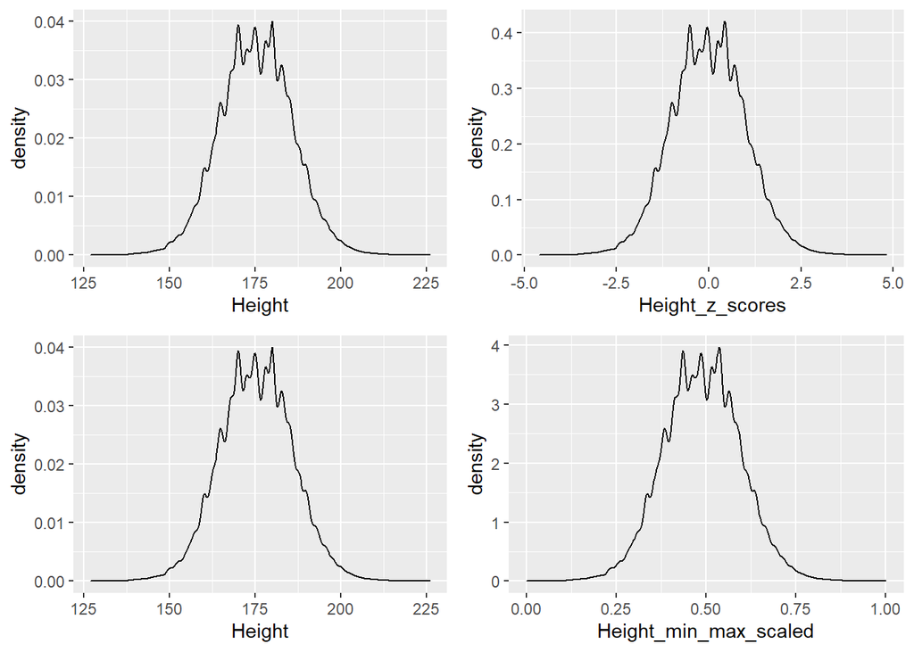

```r
height = ggplot(a_data, aes(Height))+geom_density()
height_z = ggplot(a_data, aes(Height_z_scores))+geom_density()
height_sc = ggplot(a_data, aes(Height_min_max_scaled))+geom_density()
plot_grid(height,height_z,height,height_sc,ncol = 2, nrow = 2)
```

```r
t.test(a_data[!is.na(a_data$Sex) & a_data$Sex == "M",]$Height, a_data[!is.na(a_data$Sex) & a_data$Sex == "F",]$Height)
```

```
##
##  Welch Two Sample t-test
##
## data:  a_data[!is.na(a_data$Sex) & a_data$Sex == "M", ]$Height and a_data[!is.na(a_data$Sex) & a_data$Sex == "F", ]$Height
## t = 263.1, df = 139788, p-value < 2.2e-16
## alternative hypothesis: true difference in means is not equal to 0
## 95 percent confidence interval:
##  10.93689 11.10106
## sample estimates:
## mean of x mean of y
##  178.8586  167.8396
```

```r
t.test(a_data[!is.na(a_data$Sex) & a_data$Sex == "M",]$Weight, a_data[!is.na(a_data$Sex) & a_data$Sex == "F",]$Weight)
```

```
##
##  Welch Two Sample t-test
##
## data:  a_data[!is.na(a_data$Sex) & a_data$Sex == "M", ]$Weight and a_data[!is.na(a_data$Sex) & a_data$Sex == "F", ]$Weight
## t = 297.33, df = 165275, p-value < 2.2e-16
## alternative hypothesis: true difference in means is not equal to 0
## 95 percent confidence interval:
##  15.61857 15.82585
## sample estimates:
## mean of x mean of y
##  75.74353  60.02133
```

```r
t.test(a_data[!is.na(a_data$Sex) & a_data$Sex == "M",]$Age, a_data[!is.na(a_data$Sex) & a_data$Sex == "F",]$Age)
```

```
##
##  Welch Two Sample t-test
##
## data:  a_data[!is.na(a_data$Sex) & a_data$Sex == "M", ]$Age and a_data[!is.na(a_data$Sex) & a_data$Sex == "F", ]$Age
## t = 97.814, df = 150734, p-value < 2.2e-16
## alternative hypothesis: true difference in means is not equal to 0
## 95 percent confidence interval:
##  2.493681 2.595660
## sample estimates:
## mean of x mean of y
##  26.27751  23.73284
```

```r
chisq.test(a_data$Team, a_data$Medal)
```

```
##
##  Pearson's Chi-squared test
##
## data:  a_data$Team and a_data$Medal
## X-squared = 29627, df = 1500, p-value < 2.2e-16
```

```r
t.test(a_data[!is.na(a_data$Sport) & a_data$Sport == "Basketball",]$Height, a_data[!is.na(a_data$Height),]$Height)
```

```
##
##  Welch Two Sample t-test
##
## data:  a_data[!is.na(a_data$Sport) & a_data$Sport == "Basketball", ]$Height and a_data[!is.na(a_data$Height), ]$Height
## t = 83.833, df = 3999.2, p-value < 2.2e-16
## alternative hypothesis: true difference in means is not equal to 0
## 95 percent confidence interval:
##  15.17570 15.90251
## sample estimates:
## mean of x mean of y
##  190.8781  175.3390
```